# Coursework Report

*N* removed NAs: 2

*N* removed typo: 1

*N* removed <18: 14

*N* total clean: 133

| Group | *N* | *M*<sub>age</sub> | *M*<sub>rating</sub> |
| --- | --- | --- | --- |
| Control | 63 | 21.0 | 5.50 |
| Experim | 70 | 21.2 | 6.81 |

**Main analysis results**

*t*(131) = -9.51, *p* < .001

[interactive chart not shown]

[figure not shown]

[interactive chart not shown]

# Coursework Report

Analysing Data, Spring 2020

# Methods

## Participants

There were initially 150 participants in the dataset. 14 participants were removed from the intial dataset due to ethical guidelines as these participants were under the age of 18. As well as this, 2 participants had to be removed as a result of these participants not disclosing their age and so there was no way to ensure they were over 18 years old. There was a typo of age with another participant so they were also removed from the dataset and the class was modified to numerical as it had been incorrently classed as a character variable due to this typo. In our analysis, data from 133 participants from the University of Sussex (*M*<sub>age</sub> = 21.11, *SD*<sub>age</sub> = 1.96) was used.

**Table 1. Descriptive statistics by Age**

| Mean | SD | Min | Max |
| --- | --- | --- | --- |
| 21.1 | 1.96 | 18 | 26 |

## Design

We wished to investigate whether the original red study (Elliot et al., 2010) was replicable and to discover the effect of colour on attractiveness. Colour was a factor variable with 2 levels: control group viewing a black-and-white photograph of a man on a white frame and the experimental group viewing the photograph on a red frame for 5 seconds. Attractiveness was a numerical variable given to three questions: “How attractive do you think this person is?” “How pleasant is this person to look at?” and “If I were to meet the person in this picture face to face, I would think he is attractive.” which was given on a rating scale from 1 (not at all attractive) to 9 (very attractive). A low score implies the man in the photograph is not at all attractive and a high score implies the man is very attractive. The ratings given to the three questions were averaged to calculate a composite score which indicated a perceived attractiveness rating. The current study investigated whether viewing a different colour frame around an image of a moderately attractive man influenced the mean ratings of his attractiveness, and whether the method used previously is replicable. An independent-samples *t*-test was used to analyse the data.

# Results

**Figure 1. Mean Attractiveness Ratings by Colour Condition**

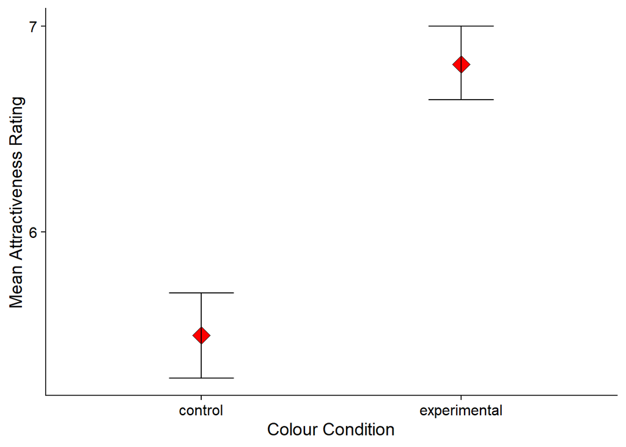

# Discussion

We investigated whether the colour red influences perceived attractiveness of a male according to a female, and whether the method used in the original study (Elliot et al., 2010) was replicable. We discovered that the colour red does influence perceived attractiveness ratings, and that the method was replicable as similar results were accumulated, with a clear higher attractiveness rating given for a photograph of a man with a red frame than a man with a white frame. The result of our *t*-test analysis suggests that whether a participant saw a photograph of a male on a white frame or a red frame does influence their ratings of their perceived attractiveness. Our results are very similar to the original results but demonstrate a slightly larger effect of colour on perceived attractiveness than the original study, which may just be due to individual differences as different female participants were used in our study than in the original study. This implies that this effect of colour on attractiveness is strong and is reliable when tested over time as 10 years have passed since the original study but similar results were found. This reliability is likely due to the innate biological influence of colour on attractiveness, as found by Setchell and Dixson (2001) in their study on mandrill monkeys whereby they discovered that as the monkeys’ dominance over their peers increased, reddening of the skin on their face and genitalia occurred. As it has been found that higher-status men are more attractive to women (DeWall & Maner, 2008), it could be inferred that women may find men more attractive when associated with the colour red due to this innate association of the colour with dominance and higher-status within a group.

As Francis (2013) suggested that publication bias and improper reporting of results had played a large role in the original study resulting in non-scientific conclusions, we intended to replicate the experiment (Elliot et al., 2010) but report with scientific integrity, reporting our results even if null findings were found, avoiding the publication bias originally found. To avoid the small sample sizes also previously used, a larger sample size was recruited, which may explain the larger effect seen in our results, which is likely to be more reliable than the previous results, as Francis (2013) notes. However, as Elliot and Maier (2013) note in their response to Francis (2013), a multitude of empirical data point to the powerful influence that the colour red has on perceived attractiveness, implying that the effect is strong and reliable. However, they also point to the small sample size, suggesting a more powerful larger sample size should be used in the future, resulting in our study putting their suggestions into action in our replication of the original study.

Although Elliot and Maier (2013) note that many replications and further research demonstrate similar results to the original study on the red effect, one replication by Hesslinger, Goldbach and Carbon (2015) did not find any effect of red on perceived attractiveness ratings at all in their direct replication of the experiment we also replicated. They instead discovered that apparel style was more important, with women finding men with formal clothing on more attractive than those wearing casual clothing. These results differ from the pattern of results that we observed in our replication, suggesting that further replications need to be conducted to discover other mediators, as well as the apparel mediator that was observed previously. Until further replications have been conducted, it is difficult to accurately determine whether the red effect is as strong as once believed, although our results do suggest that the red effect is stronger than ever, even stronger than the effect originally observed (Elliot et al., 2010).

As suggested by Peperkoorn, Roberts & Pollet (2016), the red effect may be mediated by viewing time of the photograph, thus in further research, viewing time should be a dependant variable whereby an effect is observed and analysed. As we replicated the original experiment, using only 5 seconds as a time frame, this was not implemented in our experiment, and so should be included in future research on the red effect to discover whether viewing time is a mediator of the association between colour and attractiveness. As well as this highlighted area for future research, to avoid the over-reliance on quantitative data, qualitative data should be accumulated also, perhaps with an interview or written questionnaire obtaining opinions on the looks of the male in the photograph, which would formulate a wider picture of the red effect as qualitative data provides a wider understanding of certain behaviours with thoughts and feelings providing opportunity for in-depth analysis (Eyisi, 2016). Another interesting area for further research is investigating how sexuality mediates the red effect and discovering whether participants from the LGBTQ+ community differ in the way they are influenced by colour in their perceived attractiveness of others. Also, as Hesslinger, Goldbach and Carbon (2015) suggest, using just one moderately attractive man in the photographs limits the variability of physical attractiveness that is seen worldwide in the general population, thus, a wider range of attractiveness levels should be observed rather than the general ‘average’ male to formulate a more robust test of the red effect. Therefore, there are large areas of this effect of colour on attractiveness that have been absent from previous research and so research should be continued to achieve answers to these valuable questions that would have important implications in our society, such as determining the impact of sexuality on the red effect.

Thus, our results support our hypothesis that colour affects attractiveness ratings of males given by females without the females being aware that this influence is present, as well as highlighting the replicability of the method previously formulated (Elliot et al., 2010). However, further replications need to be conducted in order to investigate the true effect that the colour red has on perceived attractiveness, as well as discovering mediators of this relationship.

# References

DeWall, C., & Maner, J. (2008). High Status Men (but Not Women) Capture the Eye of the Beholder. *Evolutionary Psychology, 6*(2), 147470490800600. doi: 10.1177/147470490800600209

Elliot, A., & Maier, M. (2013). The red-attractiveness effect, applying the Ioannidis and Trikalinos (2007b) test, and the broader scientific context: A reply to Francis (2013). *Journal Of Experimental Psychology: General, 142*(1), 297-300. doi: 10.1037/a0029592

Elliot, A., Niesta Kayser, D., Greitemeyer, T., Lichtenfeld, S., Gramzow, R., Maier, M., & Liu, H. (2010). Red, rank, and romance in women viewing men. *Journal Of Experimental Psychology: General, 139*(3), 399-417. https://doi.org/10.1037/a0019689

Eyisi, D. (2016). The Usefulness of Qualitative and Quantitative Approaches and Methods in Researching Problem-Solving Ability in Science Education Curriculum. *Journal of Education and Practice, 7*(15), 91-100.

Francis, G. (2013). Publication bias in “Red, rank, and romance in women viewing men,” by Elliot et al. (2010). *Journal of Experimental Psychology: General, 142*(1), 292-296. doi: 10.1037/a0027923

Hesslinger, V., Goldbach, L., & Carbon, C. (2015). Men in red: A reexamination of the red-attractiveness effect. *Psychonomic Bulletin & Review, 22*(4), 1142-1148. doi: 10.3758/s13423-015-0866-8

Setchell, J., & Dixson, A. (2001). Circannual changes in the secondary sexual adornments of semifree-ranging male and female mandrills (Mandrillus sphinx). *American Journal of Primatology, 53*(3), 109-121. doi: 10.1002/1098-2345(200103)53:3<109::aid-ajp2>3.0.co;2-i